# IMDB Sentiment Analysis (Lasso)

Biostat 203B

Author

Dr. Hua Zhou @ UCLA

Published

March 4, 2025

## 1 Set up

Display system information for reproducibility.

**Python**

```python
import IPython
print(IPython.sys_info())
```

```
{'commit_hash': '49914f938',
 'commit_source': 'installation',
 'default_encoding': 'utf-8',
 'ipython_path': '/Users/huazhou/Library/Python/3.9/lib/python/site-packages/IPython',
 'ipython_version': '8.18.1',
 'os_name': 'posix',
 'platform': 'macOS-15.3.1-arm64-arm-64bit',
 'sys_executable': '/Library/Developer/CommandLineTools/usr/bin/python3',
 'sys_platform': 'darwin',
 'sys_version': '3.9.6 (default, Nov 11 2024, 03:15:38) \n'
                '[Clang 16.0.0 (clang-1600.0.26.6)]'}
```

**R**

Load libraries.

**Python**

```python
# Load the pandas library
import pandas as pd
# Load numpy for array manipulation
import numpy as np
# Load seaborn plotting library
import seaborn as sns
import matplotlib.pyplot as plt

# Set font sizes in plots
sns.set(font_scale = 1.2)
# Display all columns
pd.set_option('display.max_columns', None)

# Load Tensorflow and Keras
import tensorflow as tf
from tensorflow import keras
from tensorflow.keras import layers
```

**R**

```r
library(keras)
library(tidyverse)
library(tidymodels)
library(glmnet)
library(pROC)
```

## 2 Prepare data

From documentation:

> Dataset of 25,000 movies reviews from IMDB, labeled by sentiment (positive/negative). Reviews have been preprocessed, and each review is encoded as a sequence of word indexes (integers). For convenience, words are indexed by overall frequency in the dataset, so that for instance the integer “3” encodes the 3rd most frequent word in the data. This allows for quick filtering operations such as: “only consider the top 10,000 most common words, but eliminate the top 20 most common words”.

Retrieve IMDB data. We restrict to the 10,000 most frequently-used words and tokens.

**Python**

```python
max_features = 10000

(x_train, y_train), (x_test, y_test) = keras.datasets.imdb.load_data(num_words = max_features)
```

```
Downloading data from https://storage.googleapis.com/tensorflow/tf-keras-datasets/imdb.npz
```

Data dimensions.

```python
x_train.shape
```

```
(25000,)
```

```python
y_train.shape
```

```
(25000,)
```

```python
x_test.shape
```

```
(25000,)
```

```python
y_test.shape
```

```
(25000,)
```

```python
# Indices of the first 12 words of the first training document
x_train[0][0:11]
```

```
[1, 14, 22, 16, 43, 530, 973, 1622, 1385, 65, 458]
```

To decode the reviews:

```python
# Use the default parameters to keras.datasets.imdb.load_data
start_char = 1
oov_char = 2
index_from = 3

# Retrieve the word index file mapping words to indices
word_index = keras.datasets.imdb.get_word_index()
```

```
Downloading data from https://storage.googleapis.com/tensorflow/tf-keras-datasets/imdb_word_index.json
```

```python
# Reverse the word index to obtain a dict mapping indices to words
# And add `index_from` to indices to sync with `x_train`
inverted_word_index = dict(
    (i + index_from, word) for (word, i) in word_index.items()
)

# Update `inverted_word_index` to include `start_char` and `oov_char`
inverted_word_index[start_char] = "[START]"
inverted_word_index[oov_char] = "[OOV]"
# Decode the first sequence in the dataset
" ".join(inverted_word_index[i] for i in x_train[0])
```

```
"[START] this film was just brilliant casting location scenery story direction everyone's really suited the part they played and you could just imagine being there robert [OOV] is an amazing actor and now the same being director [OOV] father came from the same scottish island as myself so i loved th…
```

**R**

```r
max_features <- 10000

imdb <- dataset_imdb(num_words = max_features)
x_train <- imdb$train$x
y_train <- imdb$train$y
x_test <- imdb$test$x
y_test <- imdb$test$y
```

Data dimensions.

```r
# Training set
length(x_train)
```

```
[1] 25000
```

```r
table(y_train)
```

```
y_train
    0     1
12500 12500
```

```r
# Test set
length(x_test)
```

```
[1] 25000
```

```r
table(y_test)
```

```
y_test
    0     1
12500 12500
```

```r
# Indices of the first 12 words of the first training document
x_train[[1]][1:12]
```

```
 [1]    1   14   22   16   43  530  973 1622 1385   65  458 4468
```

Function for decoding the IMDB reviews:

```r
word_index <- dataset_imdb_word_index()

decode_review <- function(text, word_index) {
  word <- names(word_index)
  idx <- unlist(word_index, use.names = FALSE)
  word <- c("<PAD>", "<START>", "<UNK>", "<UNUSED>", word)
  idx <- c(0:3, idx + 3)
  words <- word[match(text, idx, 2)]
  paste(words, collapse = " ")
}

decode_review(x_train[[1]], word_index)
```

```
[1] "<START> this film was just brilliant casting location scenery story direction everyone's really suited the part they played and you could just imagine being there robert <UNK> is an amazing actor and now the same being director <UNK> father came from the same scottish island as myself so i love…
```

Create the bag of words matrices.

**Python**

```python
from scipy import sparse

def one_hot(sequences, dimension):
  seqlen = [len(sequences[i]) for i in range(len(sequences))]
  n = len(seqlen)
  rowind = np.repeat(range(n), seqlen)
  colind = np.concatenate(sequences)
  vals = np.ones(len(rowind))
  return sparse.coo_matrix((vals, (rowind, colind)), shape = (n, dimension)).tocsc()

# Train
x_train_1h = one_hot(x_train, 10000)
x_train_1h.shape
```

```
(25000, 10000)
```

```python
# Sparsity of train set
x_train_1h.count_nonzero() / np.prod(x_train_1h.shape)
```

```
0.013169872
```

```python
# Test
x_test_1h = one_hot(x_test, 10000)
x_test_1h.shape
```

```
(25000, 10000)
```

```python
# Sparsity of test set
x_test_1h.count_nonzero() / np.prod(x_test_1h.shape)
```

```
0.012874312
```

**R**

```r
library(Matrix)

one_hot <- function(sequences, dimension) {
  seqlen <- sapply(sequences, length)
  n <- length(seqlen)
  rowind <- rep(1:n, seqlen)
  colind <- unlist(sequences)
  sparseMatrix(
    i = rowind,
    j = colind,
    dims = c(n, dimension)
  )
}

# Train
x_train_1h <- one_hot(x_train, 10000)
dim(x_train_1h)
```

```
[1] 25000 10000
```

```r
# Proportion of nonzeros
nnzero(x_train_1h) / (25000 * 10000)
```

```
[1] 0.01316987
```

```r
# Test
x_test_1h <- one_hot(x_test, 10000)
dim(x_test_1h)
```

```
[1] 25000 10000
```

```r
# Proportion of nonzeros
nnzero(x_test_1h) / (25000 * 10000)
```

```
[1] 0.01287431
```

## 3 Lasso

### 3.1 Training Lasso

**Python**

We use logistic regression model in [scikit-learn](https://scikit-learn.org/stable/modules/generated/sklearn.linear_model.LogisticRegression.html):

```python
from sklearn.linear_model import LogisticRegression
from sklearn.pipeline import Pipeline

logit_mod = LogisticRegression(
  penalty = 'l1',
  solver = 'liblinear',
  warm_start = True
  )

pipe = Pipeline(steps = [
  ("model", logit_mod)
])
pipe
```

```
Pipeline(steps=[('model',
                 LogisticRegression(penalty='l1', solver='liblinear',
                                    warm_start=True))])
```

Set up tuning grid for $C = 1/\alpha$.

```python
C_grid = np.logspace(start = -3, stop = 3, base = 10, num = 100)

tuned_parameters = {"model__C": C_grid}
```

Cross-validation:

```python
from sklearn.model_selection import GridSearchCV

# Set up CV
n_folds = 10
search = GridSearchCV(
  pipe,
  tuned_parameters,
  cv = n_folds,
  scoring = "roc_auc",
  # Refit the best model on the whole data set
  refit = True,
  # Adjust n_jobs according to hardware
  n_jobs = 8
  )

search.fit(x_train_1h, y_train)
```

```
GridSearchCV(cv=10,
             estimator=Pipeline(steps=[('model',
                                        LogisticRegression(penalty='l1',
                                                           solver='liblinear',
                                                           warm_start=True))]),
             n_jobs=8,
             param_grid={'model__C': array([1.00000000e-03, 1.14975700e-03, 1.32194115e-03, 1.51991108e-03,
       1.74752840e-03, 2.00923300e-03, 2.31012970e-03, 2.65608778e-03,
       3.05385551e-03, 3.51119173e-03, 4.03701726e-03, 4.64158883e-03,
       5.3366...
       4.03701726e+01, 4.64158883e+01, 5.33669923e+01, 6.13590727e+01,
       7.05480231e+01, 8.11130831e+01, 9.32603347e+01, 1.07226722e+02,
       1.23284674e+02, 1.41747416e+02, 1.62975083e+02, 1.87381742e+02,
       2.15443469e+02, 2.47707636e+02, 2.84803587e+02, 3.27454916e+02,
       3.76493581e+02, 4.32876128e+02, 4.97702356e+02, 5.72236766e+02,
       6.57933225e+02, 7.56463328e+02, 8.69749003e+02, 1.00000000e+03])},
             scoring='roc_auc')
```

**R**

```r
cvres <- cv.glmnet(
  x_train_1h,
  y_train,
  nfolds = 10,
  family = "binomial",
  # loss to use for CV
  type.measure = "auc",
  # pass through to glmnet
  standardize = FALSE,
)
```

Visualize CV result:

**Python**

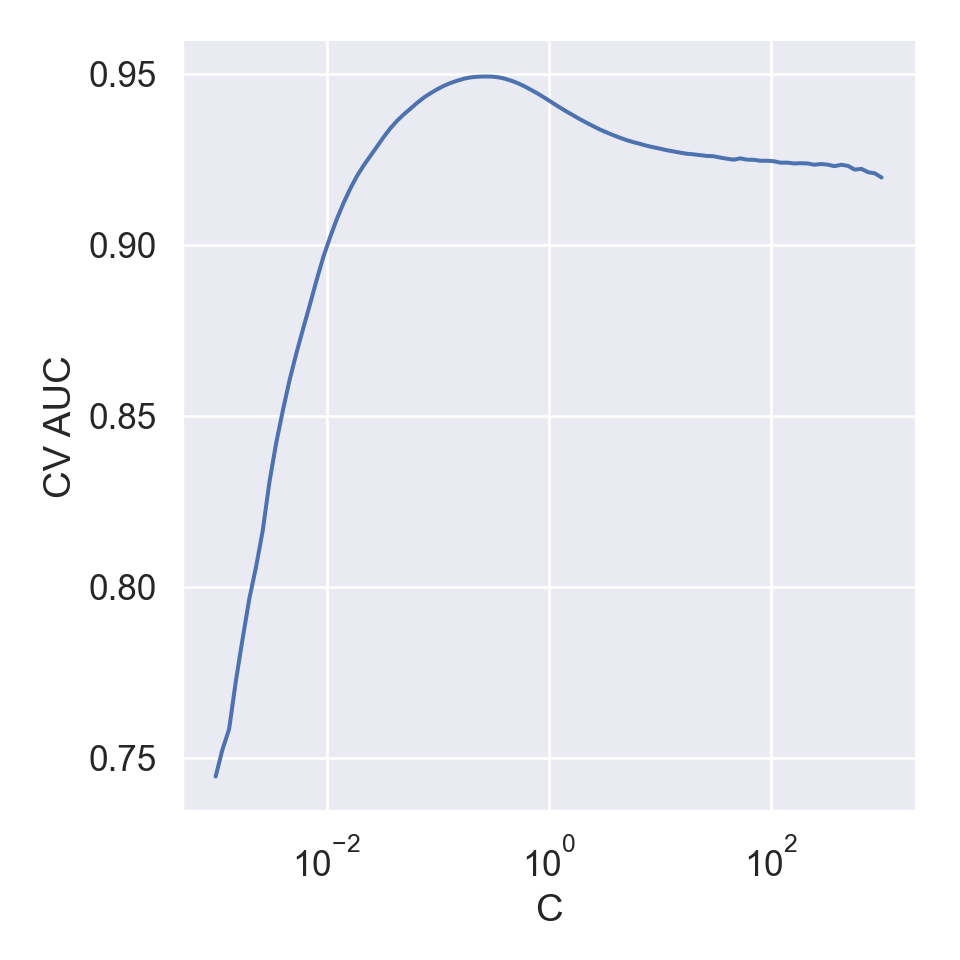

```python
cvres = pd.DataFrame(
  {
  "C": np.array(search.cv_results_["param_model__C"]),
  "aucroc": search.cv_results_["mean_test_score"]
  }
)

plt.figure()
sns.relplot(
  kind = "line",
  data = cvres,
  x = "C",
  y = "aucroc"
  ).set(
    xscale = "log",
    xlabel = "C",
    ylabel = "CV AUC"
);
plt.show()
```

**R**

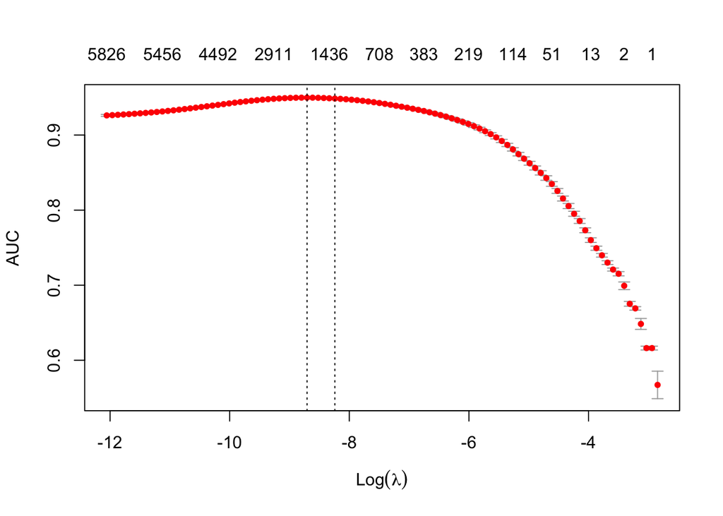

```r
plot(cvres)
```

Which words have the largest effect sizes in the lasso penalized logistic regression?

**Python**

```python
search.best_estimator_['model']
```

```
LogisticRegression(C=0.26560877829466867, penalty='l1', solver='liblinear',
                   warm_start=True)
```

```python
betahat = search.best_estimator_['model'].coef_[0]
ix = np.argsort(abs(betahat))[::-1]

pd.DataFrame({
  'word': [inverted_word_index[i + 1 + index_from] for i in ix[range(10)]],
  'beta': betahat[ix[range(10)]]
})
```

```
           word      beta
0  entertaining -1.757349
1     developed -1.641652
2     structure  1.614938
3      surprise -1.556530
4           fun -1.513894
5          knew  1.304302
6            40  1.277731
7             v -1.268735
8      remember -1.214608
9        angles -1.204306
```

**R**

```r
betahat_sorted <- sort(
  as.vector(abs(coef(cvres))),
  decreasing = TRUE,
  index.return = TRUE
  )

tibble(
  word = str_split(decode_review(betahat_sorted$ix[1:10], word_index), ' ')[[1]],
  beta = coef(cvres)[betahat_sorted$ix[1:10]]
)
```

```
# A tibble: 10 × 2
   word        beta
   <chr>      <dbl>
 1 cinema     -1.65
 2 girl       -1.60
 3 knows       1.38
 4 premise    -1.35
 5 loves      -1.30
 6 video      -1.25
 7 opposite   -1.19
 8 australian  1.16
 9 necessary   1.13
10 nearly     -1.10
```

### 3.2 Testing Lasso

**Python**

Test AUC:

```python
from sklearn.metrics import accuracy_score, roc_auc_score

roc_auc_score(
  y_test,
  search.best_estimator_.predict_proba(x_test_1h)[:, 1]
  )
```

```
0.9482194176000001
```

Test accuracy:

```python
accuracy_score(
  y_test,
  search.best_estimator_.predict(x_test_1h)
  )
```

```
0.8814
```

**R**

Test AUC:

```r
auc(y_test, predict(cvres, x_test_1h, type = "response"))
```

```
Area under the curve: 0.9489
```

Test accuracy:

```r
sum(y_test == predict(cvres, x_test_1h, type = "class")) / length(y_test)
```

```
[1] 0.88104
```